# Ford GoBike System Dataset Exploration

##### Does duration of trips vary from month to month? In which months duration will be highest?

```
(0, 50)
```

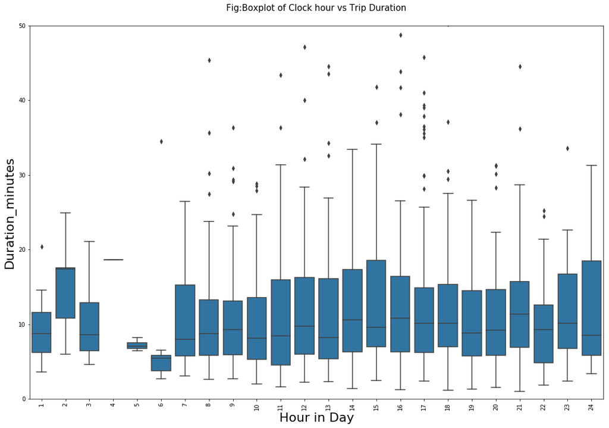

```python
plt.figure(figsize = [18, 12])
sb.boxplot(x = a.start_time.dt.hour,  y = a.duration_min, color = base_color);
plt.title("Fig:Boxplot of Clock hour vs Trip Duration", fontsize=15, y=1.03);
plt.xticks(np.arange(0,24,1),np.arange(1,25,1), rotation = 90)
plt.xlabel('Hour in Day', size =22)
plt.ylabel('Duration_minutes', size =22)
plt.ylim((0,50))
```

##### Does duration of trips vary from hour to hour? In which hour duration will be highest?

> Duration of trips vs Hours of day, boxplot shows that there is a trend between duration of trips and clock hours. Median of duration(min) is highest for some particular hours. In general median is around 10 minutes and 75 percentile is between 10 minutes and 20 minutes. (This is from a sample of 50,000 entries)

```
(0, 40)
```

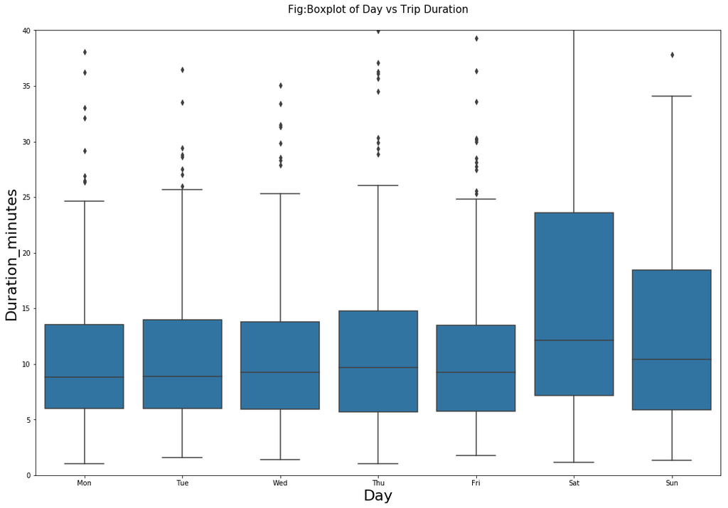

```python
plt.figure(figsize = [18, 12])
sb.boxplot(data = a , x ='start_time_dayofweek',  y ='duration_min', color = base_color);
plt.title("Fig:Boxplot of Day vs Trip Duration", fontsize=15, y=1.03);
plt.xlabel('Day', size =22)
plt.ylabel('Duration_minutes', size =22)
plt.ylim((0,40))
```

##### Does duration of trips vary according to Day of the week?

> Duration of trips vs Day, boxplot shows that there is a trend between duration of trips and Day. Median and 75 percentile of duration(min) is highest for weekend compared to weekdays.

Interestingly, Duration of Trip mostly varies for day of week and hour in day.

Before closing this section, we'll take a look at the these two variables in the next section.